# 2018_spendings

```r
library(dplyr)
library(gridExtra)
library(ggpubr)
library(stringr)
library(lubridate)
```

# Desciption: What is it?

The document describes the exploratory analysis performed on my daily spendings for 2018.

# Why?

```r
spendings <- read.csv(
  "2018_spendings.csv",
  stringsAsFactors = F
)

spendings <- spendings %>%
  mutate(
    date = as.Date(date),
    amount = as.numeric(amount),
    month_of_date = month(date)
  )

investments <- spendings %>%
  filter(main_category == 'investing')

spendings <- spendings %>%
  filter(main_category != "investing")

assets <- read.csv(
  "2018_assets.csv",
  stringsAsFactors = F
)
```

# How?

### Summarise the dataset

```r
summary(spendings)
```

```
##       date              merchant             amount
##  Min.   :2018-01-01   Length:685         Min.   :    0.50
##  1st Qu.:2018-04-28   Class :character   1st Qu.:   10.15
##  Median :2018-07-19   Mode  :character   Median :   17.68
##  Mean   :2018-07-13                      Mean   :  111.59
##  3rd Qu.:2018-10-09                      3rd Qu.:   29.11
##  Max.   :2018-12-28                      Max.   :10000.00
##  main_category      sub_category       month_of_date
##  Length:685         Length:685         Min.   : 1.000
##  Class :character   Class :character   1st Qu.: 4.000
##  Mode  :character   Mode  :character   Median : 7.000
##                                        Mean   : 6.895
##                                        3rd Qu.:10.000
##                                        Max.   :12.000
```

### How much money did I spend on traveling?

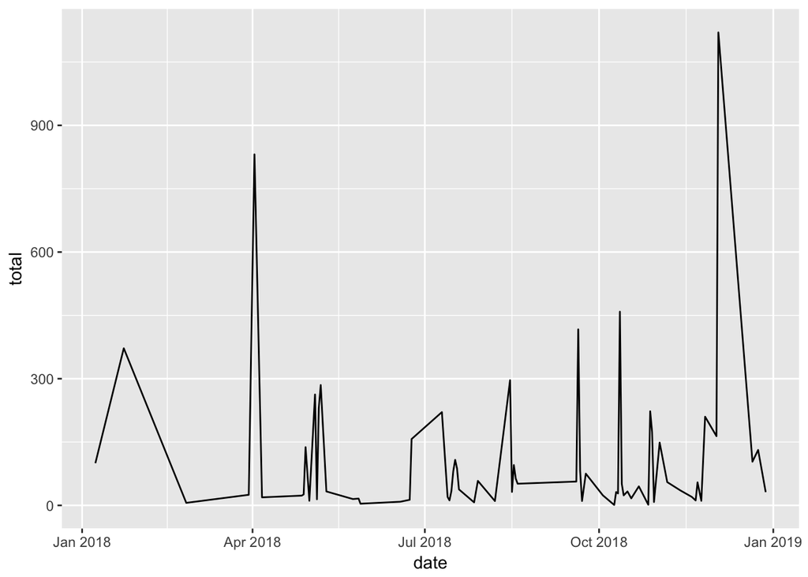

```r
spendings %>%
  filter(main_category == 'travel') %>%
  group_by(date) %>%
  summarise(total = sum(amount)) %>%
  ggplot(aes(x = date, y = total)) +
    geom_line()
```

### What is the distribution of my spending by each category?

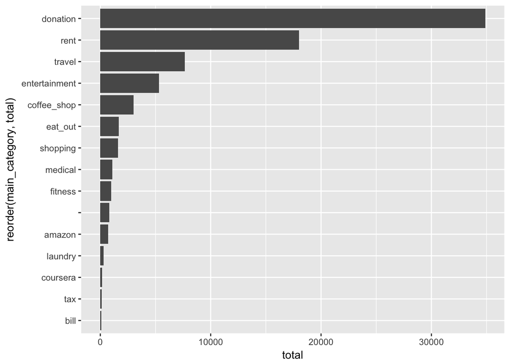

```r
spendings %>%
  group_by(main_category) %>%
  summarise(total = sum(amount)) %>%
  ggplot(aes(x = reorder(main_category, total), y = total)) +
    geom_bar(stat="identity") +
    coord_flip()
```

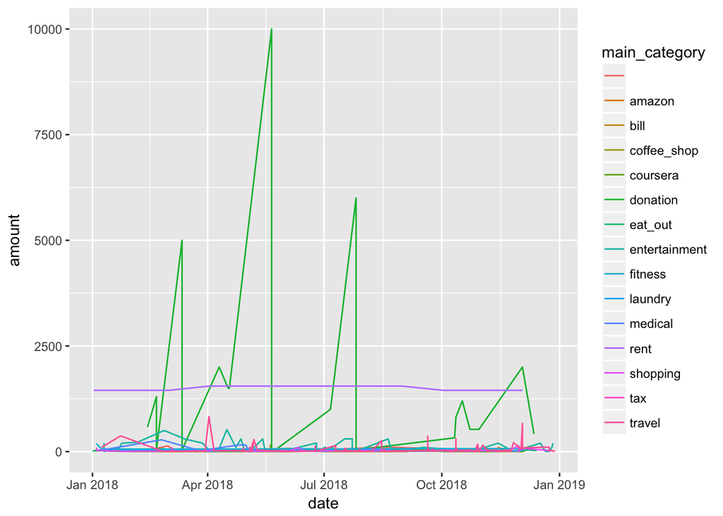

```r
spendings %>%
  ggplot(aes(x = date, y = amount, color = main_category)) +
    geom_line()
```

### Is there any immediate changes I can make in order to cut down my cost?

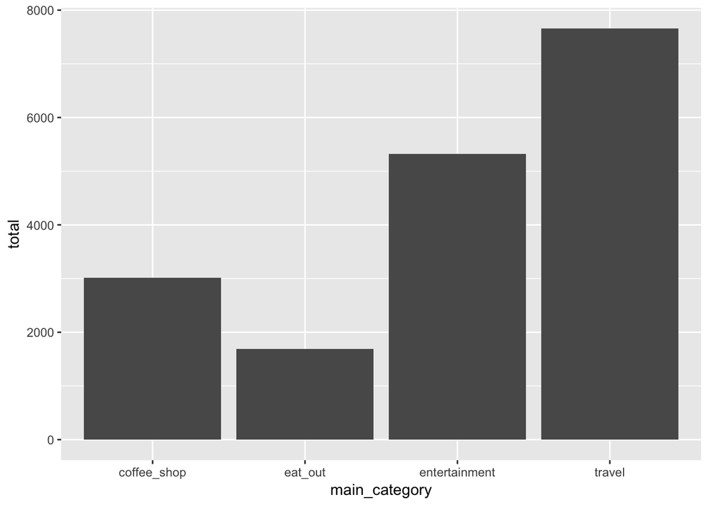

```r
spendings %>%
  filter(main_category %in% c('travel', 'entertainment', 'eat_out', 'coffee_shop')) %>%
  group_by(main_category) %>%
  summarise(total = sum(amount)) %>%
  ggplot(aes(x = main_category, y = total)) +
    geom_bar(stat="identity")
```

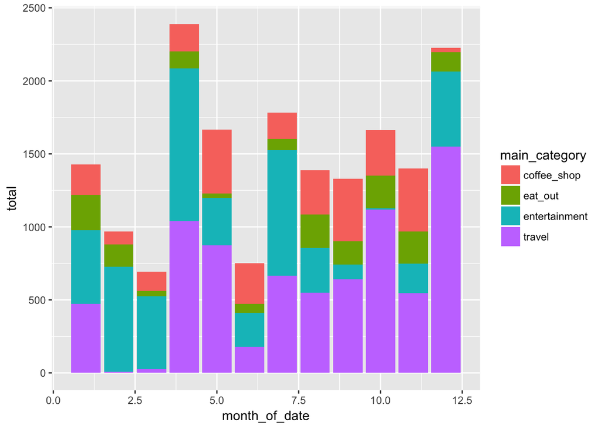

```r
spendings %>%
  filter(main_category %in% c('travel', 'entertainment', 'eat_out', 'coffee_shop')) %>%
  group_by(month_of_date, main_category) %>%
  summarise(total = sum(amount)) %>%
  ggplot(aes(x = month_of_date, y = total, fill = main_category)) +
    geom_bar(stat="identity")
```

### Did my spendings go up over time?

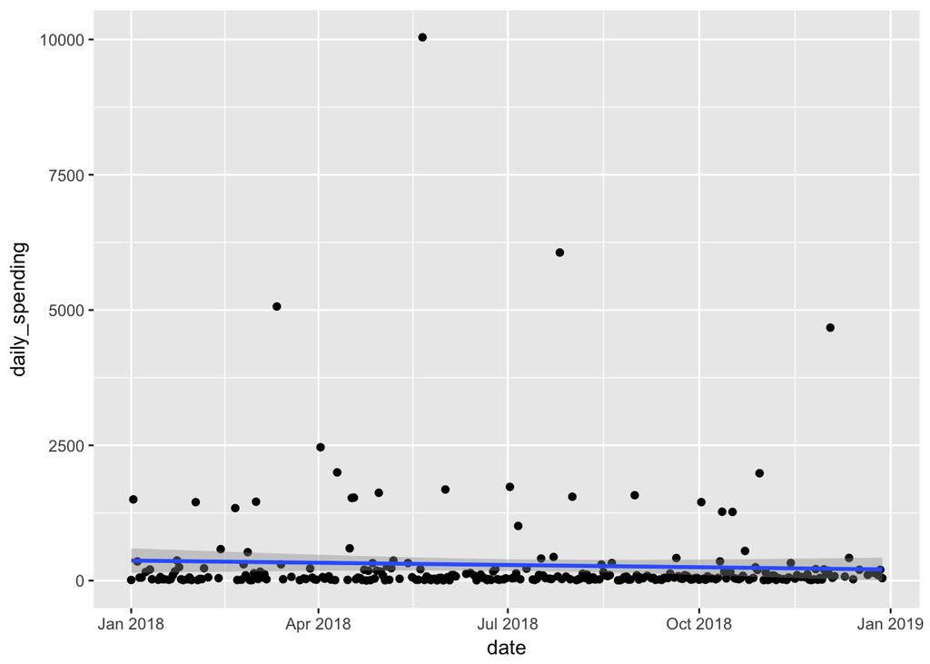

```r
spendings %>%
  group_by(date) %>%
  summarise(daily_spending = sum(amount)) %>%
  ggplot(aes(x = date, y = daily_spending)) +
    geom_point() +
    geom_smooth(method="lm")
```

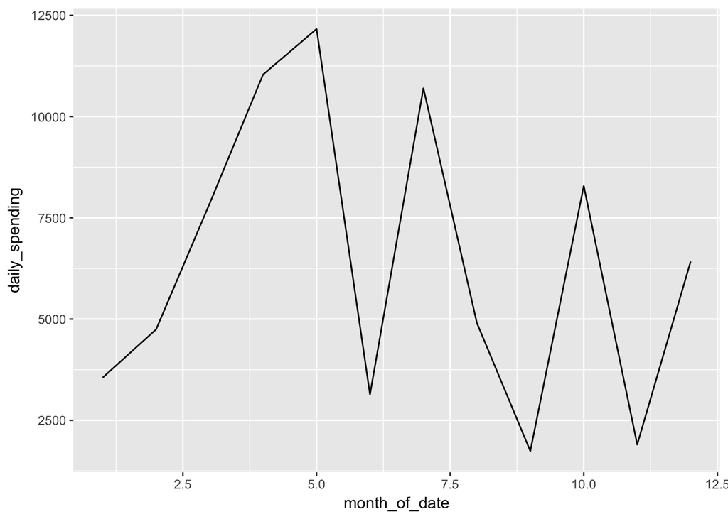

```r
spendings %>%
  group_by(month_of_date) %>%
  summarise(daily_spending = sum(amount)) %>%
  ggplot(aes(x = month_of_date, y = daily_spending)) +
    geom_line()
```

### How much do I spend on coffee shops?

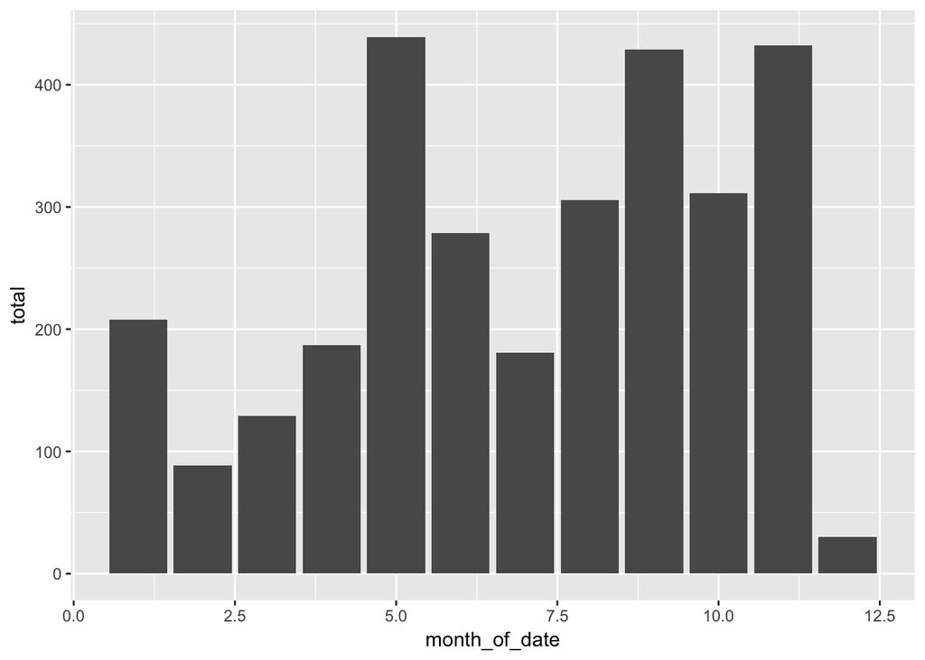

```r
spendings %>%
  filter(main_category == 'coffee_shop') %>%
  group_by(month_of_date) %>%
  summarise(total = sum(amount)) %>%
  ggplot(aes(x = month_of_date, y = total)) +
    geom_bar(stat="identity")
```

What does coffee shop visits look like by categories?

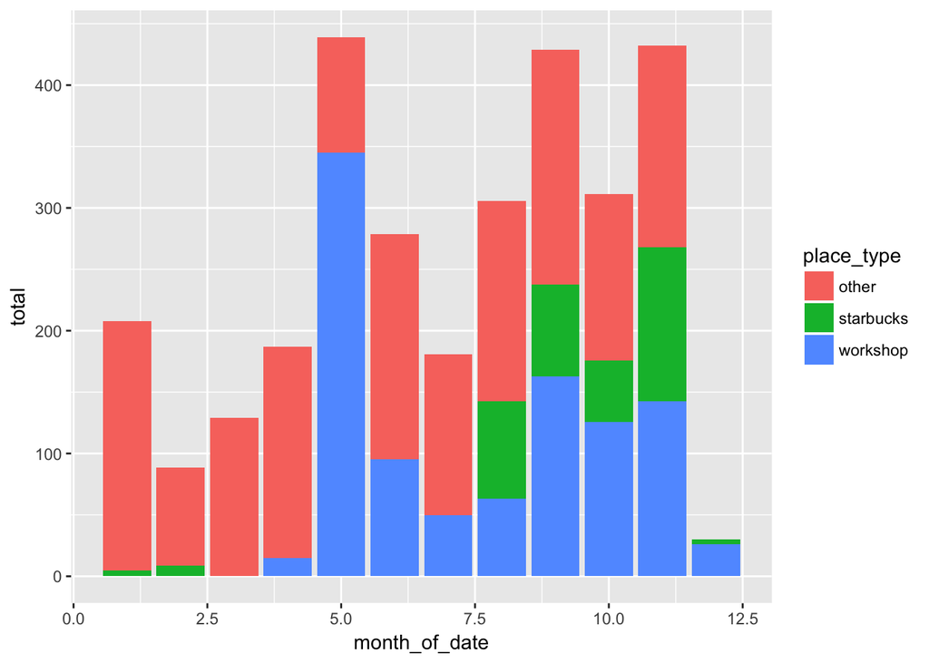

```r
spendings %>%
  filter(main_category == 'coffee_shop') %>%
  mutate(place_type = ifelse(grepl('WORKSHOP', merchant), 'workshop', ifelse(grepl('STARBUCKS', merchant), 'starbucks', 'other'))) %>%   group_by(month_of_date, place_type) %>%
  summarise(total = sum(amount)) %>%
  ggplot(aes(x = month_of_date, y = total, fill = place_type)) +
    geom_bar(stat="identity")
```

```r
(spendings %>%
  filter(main_category == 'coffee_shop') %>%
  summarise(total = sum(amount)))$total / 12.0
```

```
## [1] 251.6092
```

I should not spend more than 100$/month on coffee shops.

### How much do I spend on eating out?

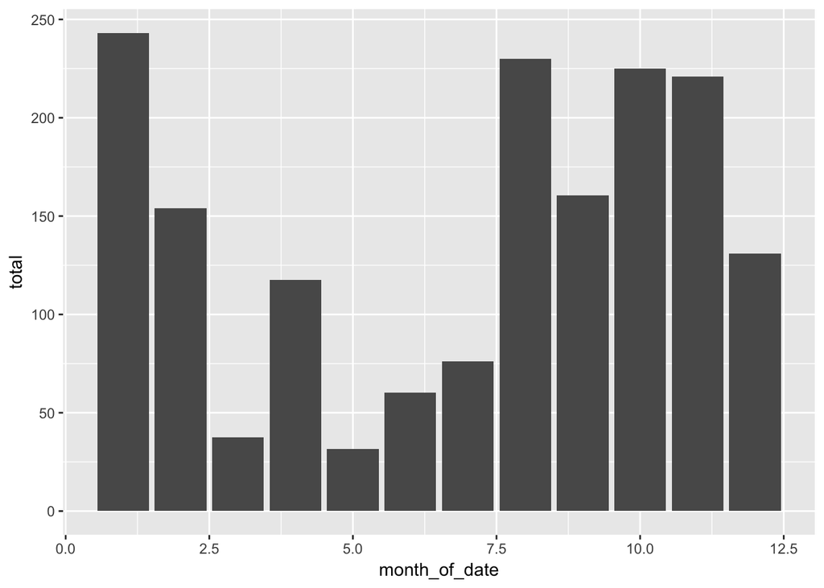

```r
spendings %>%
  filter(main_category == 'eat_out') %>%
  group_by(month_of_date) %>%
  summarise(total = sum(amount)) %>%
  ggplot(aes(x = month_of_date, y = total)) +
    geom_bar(stat = 'identity')
```

### How much can I save by traveling half of what I currently do?

Total travel spending is around:

```r
spendings %>%
  filter(main_category == 'travel') %>%
  summarise(total = sum(amount))
```

| total |
| --- |
| 7662.03 |

### How much should a new entertainment allocated budget per month?

Current entertainment spending pattern:

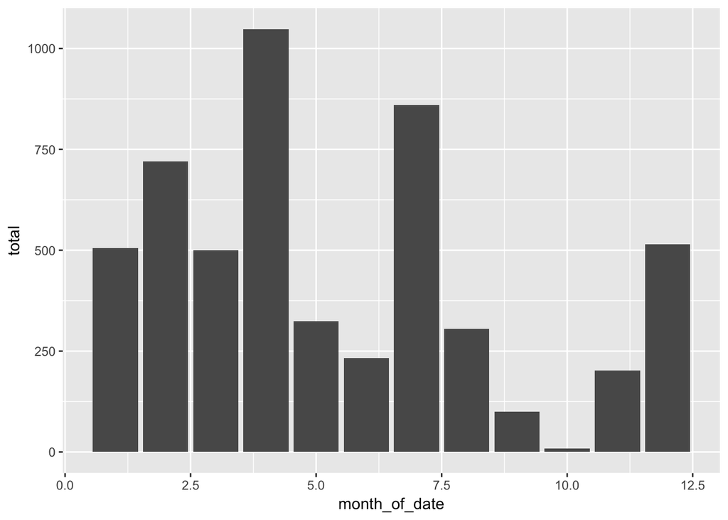

```r
spendings %>%
  filter(main_category == 'entertainment') %>%
  group_by(month_of_date) %>%
  summarise(total = sum(amount)) %>%
  ggplot(aes(x = month_of_date, y = total)) +
    geom_bar(stat = 'identity')
```

```r
(spendings %>%
  filter(main_category == 'entertainment') %>%
  summarise(total = sum(amount)))$total / 12.0
```

```
## [1] 443.4433
```

New monthly entertainment budget is 250$/month

### Is my rent the biggest spending every month?

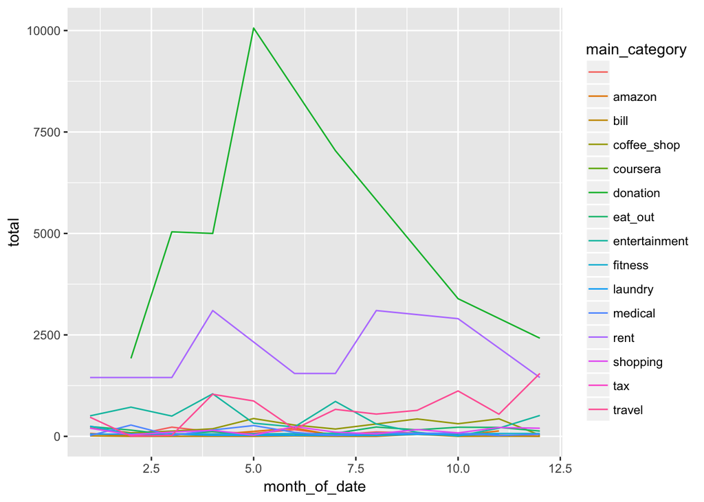

```r
spendings %>%
  group_by(month_of_date, main_category) %>%
  summarise(total = sum(amount)) %>%
  ggplot(aes(x = month_of_date, y = total, color = main_category)) +
    geom_line()
```

### How does my spending compare against the US average?

According to Bureau of Labor Statistics, average family income in 2016 was around 75000, with 90% of it is early expenditure.

So yearly spending is around:

```r
75000 * 0.9
```

```
## [1] 67500
```

My total spending of 2018 was around:

```r
spendings %>%
  summarise(total = sum(amount))
```

| total |
| --- |
| 76438.69 |

https://www.usatoday.com/story/money/personalfinance/budget-and-spending/2018/05/08/how-does-average-american-spend-paycheck/34378157/

### How much is my total asset?

```r
(assets %>% summarise(total = sum(amount)))$total
```

```
## [1] 97474.4
```

### Do I have an enough emergency fund?

```r
avg_monthly_spending <- (spendings %>% summarise(total = sum(amount)))$total / 12.0
current_liquid_asset_value <- (assets %>% filter(category == 'liquid') %>% summarise(total = sum(amount)))$total

(num_months_of_emergency <- current_liquid_asset_value / avg_monthly_spending)
```

```
## [1] 7.262091
```

# What?

- My maximum travel budget is 1000$/month
- Every month, the highest spending should be investing
- 250$/month is allocated for entertainment
- 100$/month is allocated for coffee shop spending

# Timeline

1. Finish 1-pager [2018-01-22]
2. Final deliverable [2018-02-29]